# Assignment 3

     There is no significant linear relationship between flight distance and departure delay.

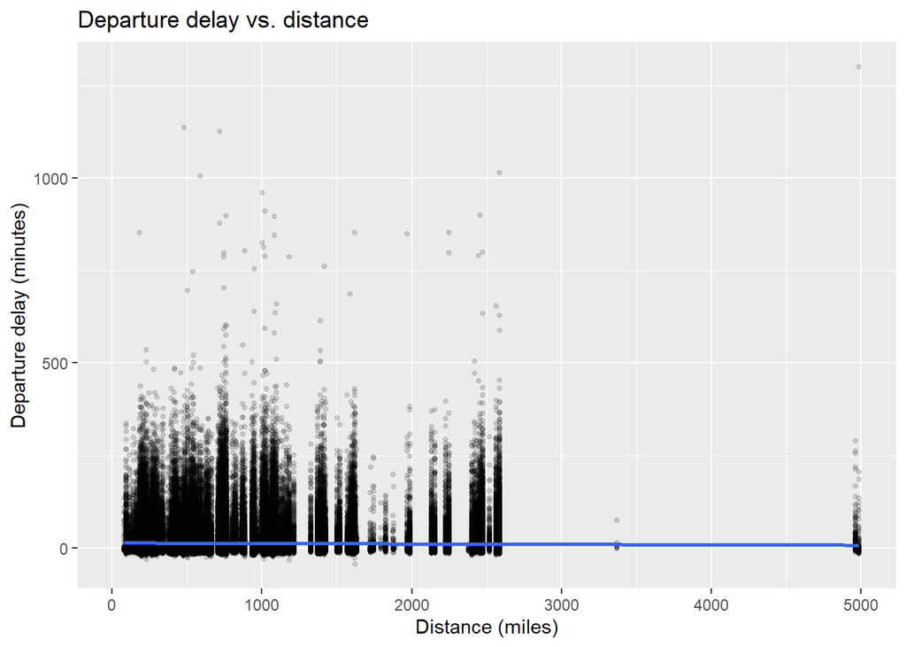

   ```r
   library(ggplot2)

   df %>%
     ggplot(aes(distance, dep_delay)) +
     geom_point(alpha = 0.15, size = 1) +
     geom_smooth(method = "lm", se = FALSE) +
     labs(title = "Departure delay vs. distance",
          x = "Distance (miles)", y = "Departure delay (minutes)")
   ```

   - Was the median arrival delay (arr_delay) related to the time of departure (dep_time)? The answer should show a plot and use two sentences to address this question qualitatively.

   The median arrival delay clearly varies with scheduled departure time. Flights leaving very early in the morning or late at night tend to have higher median delays, while mid-day flights show less variability and lower delays.

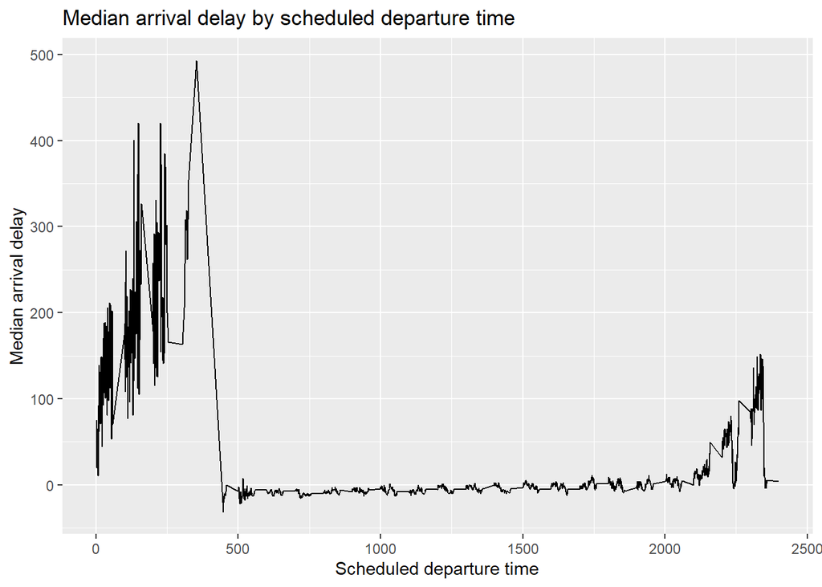

```r
df %>%
  ggplot(aes(dep_time, arr_delay)) +
  stat_summary(fun = median, geom = "line") +
  labs(title = "Median arrival delay by scheduled departure time",
       x = "Scheduled departure time", y = "Median arrival delay")
```

1. Load the RDS file located [here](https://github.com/bcbg-bio/BMIN5030/blob/master/DataFiles/brfss2022_cleaned.rds) which contains the a cleaned subset of the [2022 BRFSS dataset](https://www.cdc.gov/brfss/annual_data/annual_2022.html) as described in this [data dictionary](https://github.com/bcbg-bio/BMIN5030/blob/master/DataFiles/BRFSS2022_DataDictionary.md) to answer the following questions. We will explore some of the data and create some regression models. NOTE: We are analyzing raw BRFSS data without taking the survey design into account, and thus, our results are not representative of the US population sampled. *(10 points)*
- Load the dataset using `read_rds()`, while recalling that the link used must point to the *raw* data in GitHub. How many people reported having tested negative and positive to COVID as contained in the `covidpos` variable? How many people reported ever having had a depressive disorder as contained in the `depression` variable? What were the possible responses to the `genhealth` variable, which corresponded to the question “Would you say that in general your health is:…”, and how many responses were there to each level?

```r
data <- readRDS("C:/Users/Richard/Downloads/brfss2022_cleaned.rds")
data %>% count(covidpos)
```

```
# A tibble: 3 × 2
  covidpos      n
  <fct>     <int>
1 No       270055
2 Yes      124313
3 <NA>      50764
```

```r
data %>% count(depression)
```

```
# A tibble: 3 × 2
  depression      n
  <fct>       <int>
1 No         350910
2 Yes         91410
3 <NA>         2812
```

```r
data %>% count(genhealth)
```

```
# A tibble: 6 × 2
  genhealth      n
  <ord>      <int>
1 Excellent  71878
2 VeryGood  148444
3 Good      143598
4 Fair       60273
5 Poor       19741
6 <NA>        1198
```

- Ignore the missing responses to any variable that is being considered while you answer the following. Do you notice any trends in the distribution of responses to `covidpos` according to `race` or `income`? What about for `genhealth`? Respond by using plots and a few sentences. There is no need to create any models.

  **Higher income is associated with a higher proportion testing positive.**

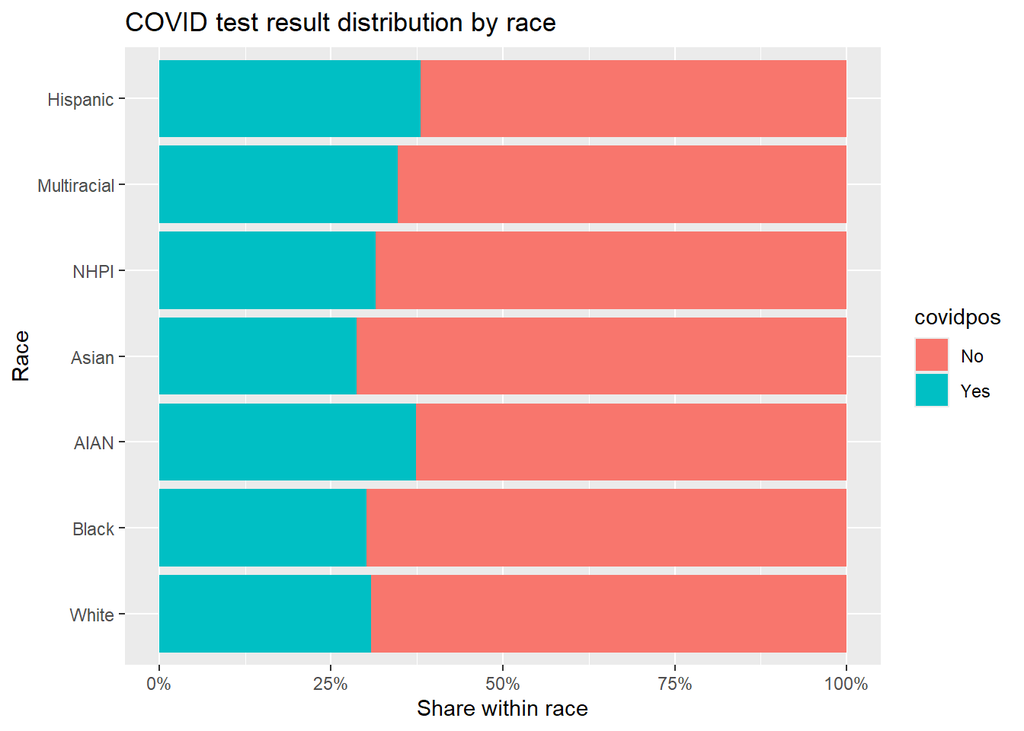

```r
data %>%
  filter(!is.na(covidpos), !is.na(race)) %>%
  group_by(race, covidpos) %>%
  summarise(n = n(), .groups = "drop_last") %>%
  mutate(pct = n / sum(n)) %>%
  ggplot(aes(race, pct, fill = covidpos)) +
  geom_col(position = "fill") +
  coord_flip() +
  scale_y_continuous(labels = scales::percent) +
  labs(title = "COVID test result distribution by race",
       x = "Race", y = "Share within race")
```

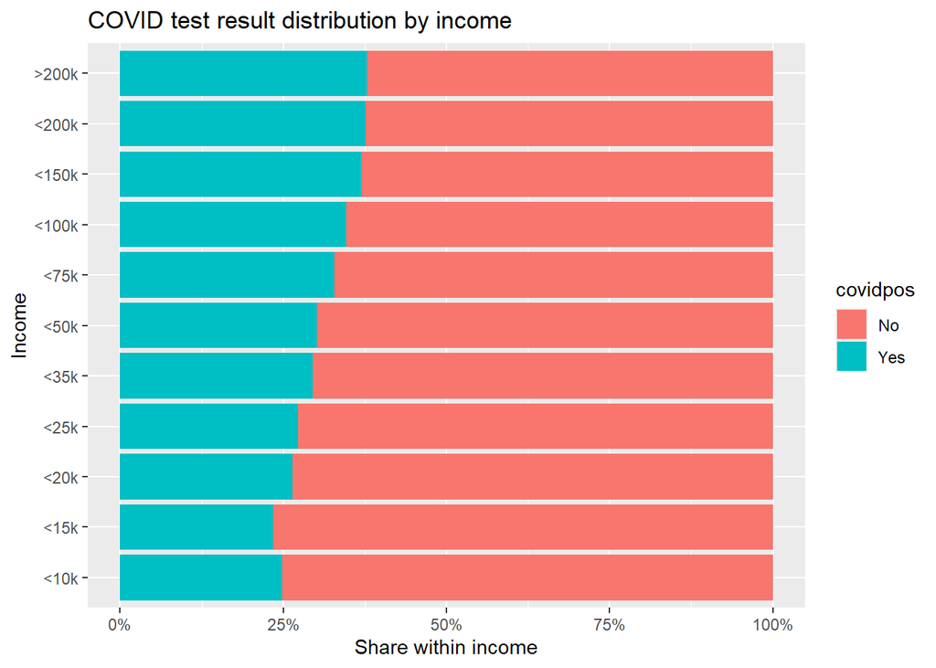

```r
data %>%
  filter(!is.na(covidpos), !is.na(income)) %>%
  group_by(income, covidpos) %>%
  summarise(n = n(), .groups = "drop_last") %>%
  mutate(pct = n / sum(n)) %>%
  ggplot(aes(income, pct, fill = covidpos)) +
  geom_col(position = "fill") +
  coord_flip() +
  scale_y_continuous(labels = scales::percent) +
  labs(title = "COVID test result distribution by income",
       x = "Income", y = "Share within income")
```

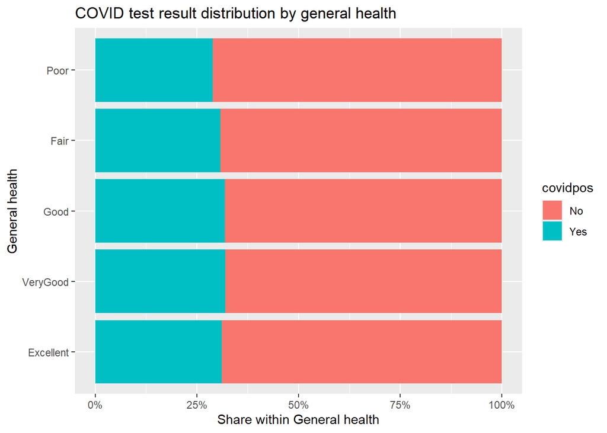

```r
data %>%
  filter(!is.na(covidpos), !is.na(genhealth)) %>%
  group_by(genhealth, covidpos) %>%
  summarise(n = n(), .groups = "drop_last") %>%
  mutate(pct = n / sum(n)) %>%
  ggplot(aes(genhealth, pct, fill = covidpos)) +
  geom_col(position = "fill") +
  coord_flip() +
  scale_y_continuous(labels = scales::percent) +
  labs(title = "COVID test result distribution by general health",
       x = "General health", y = "Share within General health")
```

- Perform bivariate analysis for the `race`, `sex`, `age`, `sleep` and `exercise` variables as predictors and `depression` as outcome. Do not relevel or transform variables. Include appropriate plots that look at the pairwise relationships between the outcomes and each predictor and create regression models to model the bivariate relationship between each outcome and each predictor. Which of the variables are associated with `depression`?

  All variables are associated with depression.

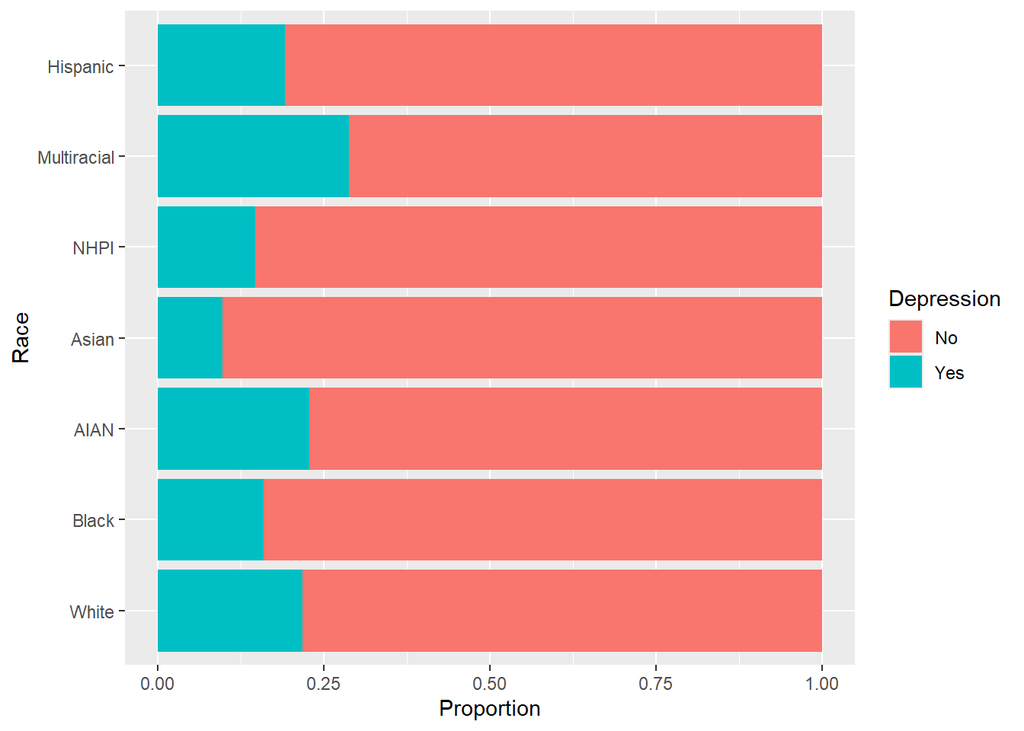

```r
data %>%
  filter(!is.na(depression), !is.na(race)) %>%
  ggplot(aes(y = race, fill = depression)) +
  geom_bar(position = "fill") +
  labs(x = "Proportion", y = "Race", fill = "Depression")
```

```r
dep_race <- glm(depression ~ race, data = data, family = "binomial")
summary(dep_race)
```

```
Call:
glm(formula = depression ~ race, family = "binomial", data = data)

Coefficients:
                 Estimate Std. Error  z value Pr(>|z|)
(Intercept)     -1.280192   0.004293 -298.191   <2e-16 ***
raceBlack       -0.386925   0.015196  -25.463   <2e-16 ***
raceAIAN         0.059679   0.029031    2.056   0.0398 *
raceAsian       -0.942821   0.029587  -31.866   <2e-16 ***
raceNHPI        -0.482175   0.057935   -8.323   <2e-16 ***
raceMultiracial  0.373175   0.023078   16.170   <2e-16 ***
raceHispanic    -0.162237   0.013041  -12.440   <2e-16 ***
---
Signif. codes:  0 '***' 0.001 '**' 0.01 '*' 0.05 '.' 0.1 ' ' 1

(Dispersion parameter for binomial family taken to be 1)

    Null deviance: 437992  on 428660  degrees of freedom
Residual deviance: 435620  on 428654  degrees of freedom
  (16471 observations deleted due to missingness)
AIC: 435634

Number of Fisher Scoring iterations: 4
```

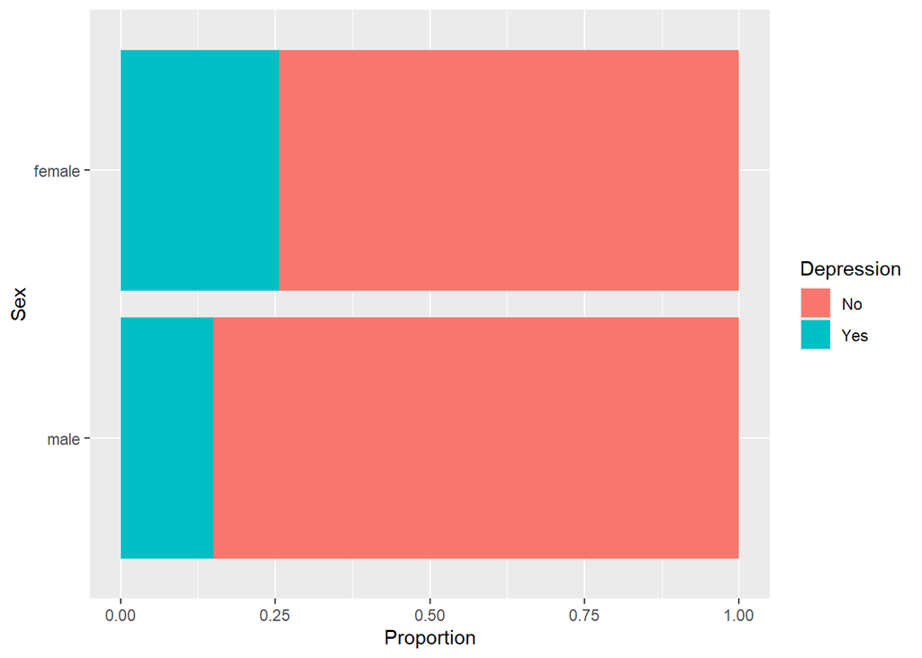

```r
data %>%
  filter(!is.na(depression), !is.na(sex)) %>%
  ggplot(aes(y = sex, fill = depression)) +
  geom_bar(position = "fill") +
  labs(x = "Proportion", y = "Sex", fill = "Depression")
```

```r
dep_sex <- glm(depression ~ sex, data = data, family = "binomial")
summary(dep_sex)
```

```
Call:
glm(formula = depression ~ sex, family = "binomial", data = data)

Coefficients:
             Estimate Std. Error z value Pr(>|z|)
(Intercept) -1.736633   0.006148 -282.48   <2e-16 ***
sexfemale    0.675537   0.007754   87.12   <2e-16 ***
---
Signif. codes:  0 '***' 0.001 '**' 0.01 '*' 0.05 '.' 0.1 ' ' 1

(Dispersion parameter for binomial family taken to be 1)

    Null deviance: 450722  on 442319  degrees of freedom
Residual deviance: 442841  on 442318  degrees of freedom
  (2812 observations deleted due to missingness)
AIC: 442845

Number of Fisher Scoring iterations: 4
```

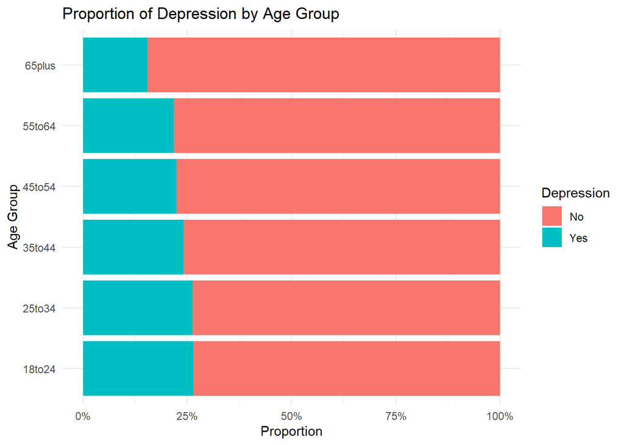

```r
age_levels <- c("18to24", "25to34", "35to44", "45to54", "55to64", "65plus")
data_cleaned <- data %>%
  filter(!is.na(age), !is.na(depression)) %>%
  mutate(age = factor(age, levels = age_levels, ordered = TRUE))
ggplot(data_cleaned, aes(y = age, fill = depression)) +
  geom_bar(position = "fill") +
  scale_x_continuous(labels = scales::percent) +
  labs(title = "Proportion of Depression by Age Group",
       y = "Age Group",
       x = "Proportion",
       fill = "Depression") +
  theme_minimal()
```

```r
dep_age <- glm(depression ~ age, data = data, family = "binomial")
summary(dep_age)
```

```
Call:
glm(formula = depression ~ age, family = "binomial", data = data)

Coefficients:
            Estimate Std. Error z value Pr(>|z|)
(Intercept) -1.02573    0.01391 -73.749  < 2e-16 ***
age25to34   -0.00673    0.01738  -0.387    0.699
age35to44   -0.12193    0.01692  -7.205 5.81e-13 ***
age45to54   -0.21603    0.01673 -12.912  < 2e-16 ***
age55to64   -0.25324    0.01627 -15.563  < 2e-16 ***
age65plus   -0.66880    0.01552 -43.087  < 2e-16 ***
---
Signif. codes:  0 '***' 0.001 '**' 0.01 '*' 0.05 '.' 0.1 ' ' 1

(Dispersion parameter for binomial family taken to be 1)

    Null deviance: 450722  on 442319  degrees of freedom
Residual deviance: 446000  on 442314  degrees of freedom
  (2812 observations deleted due to missingness)
AIC: 446012

Number of Fisher Scoring iterations: 4
```

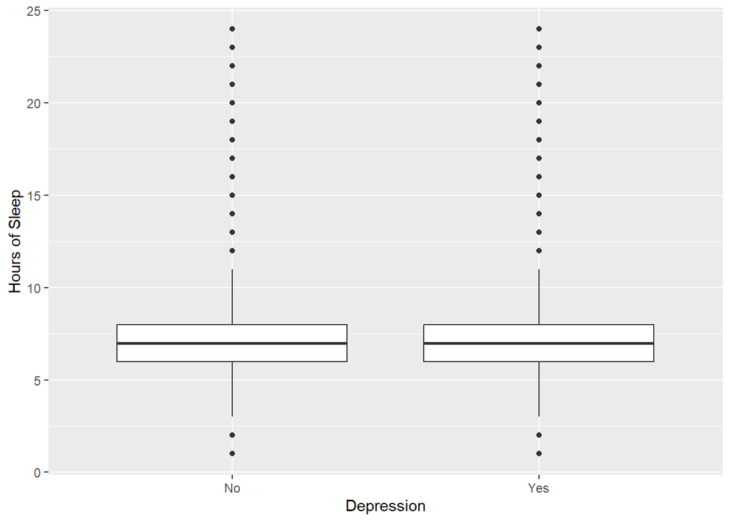

```r
data %>%
  filter(!is.na(depression), !is.na(sleep)) %>%
  ggplot(aes(x = depression, y = sleep)) +
  geom_boxplot() +
  labs(x = "Depression", y = "Hours of Sleep")
```

```r
dep_sleep <- glm(depression ~ sleep, data = data, family = "binomial")
summary(dep_sleep)
```

```
Call:
glm(formula = depression ~ sleep, family = "binomial", data = data)

Coefficients:
             Estimate Std. Error z value Pr(>|z|)
(Intercept) -0.749617   0.018141  -41.32   <2e-16 ***
sleep       -0.086030   0.002567  -33.51   <2e-16 ***
---
Signif. codes:  0 '***' 0.001 '**' 0.01 '*' 0.05 '.' 0.1 ' ' 1

(Dispersion parameter for binomial family taken to be 1)

    Null deviance: 444644  on 437096  degrees of freedom
Residual deviance: 443500  on 437095  degrees of freedom
  (8035 observations deleted due to missingness)
AIC: 443504

Number of Fisher Scoring iterations: 4
```

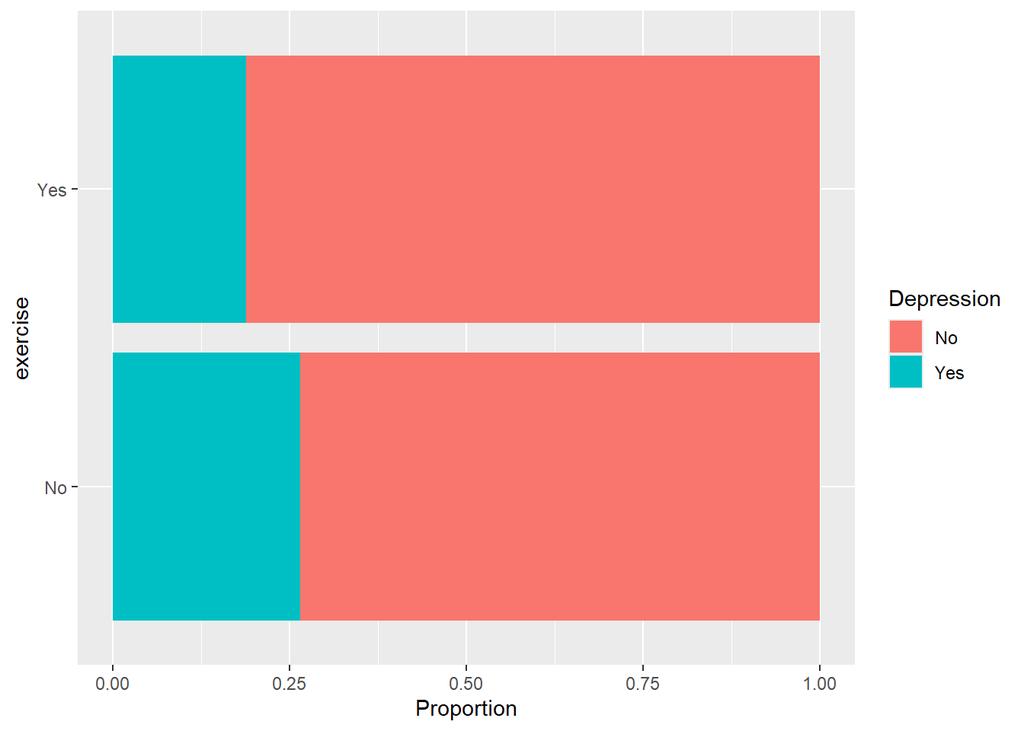

```r
data %>%
  filter(!is.na(depression), !is.na(exercise)) %>%
  ggplot(aes(y = exercise, fill = depression)) +
  geom_bar(position = "fill") +
  labs(x = "Proportion", y = "exercise", fill = "Depression")
```

```r
dep_exercise <- glm(depression ~ exercise, data = data, family = "binomial")
summary(dep_exercise)
```

```
Call:
glm(formula = depression ~ exercise, family = "binomial", data = data)

Coefficients:
             Estimate Std. Error z value Pr(>|z|)
(Intercept) -1.021085   0.006972 -146.45   <2e-16 ***
exerciseYes -0.439496   0.008252  -53.26   <2e-16 ***
---
Signif. codes:  0 '***' 0.001 '**' 0.01 '*' 0.05 '.' 0.1 ' ' 1

(Dispersion parameter for binomial family taken to be 1)

    Null deviance: 449753  on 441347  degrees of freedom
Residual deviance: 447005  on 441346  degrees of freedom
  (3784 observations deleted due to missingness)
AIC: 447009

Number of Fisher Scoring iterations: 4
```

- Create a multivariable regression model for `depression` using `sex`, `race`, `age`, `sleep`, and `exercise` as predictors. What variables are significantly associated with `depression` in the combined model? Are there substantial differences compared to the bivariate models? What does this indicate?

  All variables are significantly associated with depression in the combined model. It suggests that each of these factors has an independent association with depression that would not be explained away by the other variables.

```r
dep_multivariable <- glm(depression ~ sex + race + exercise + age + sleep + exercise, data = data, family = "binomial")
summary(dep_multivariable)
```

```
Call:
glm(formula = depression ~ sex + race + exercise + age + sleep +
    exercise, family = "binomial", data = data)

Coefficients:
                 Estimate Std. Error z value Pr(>|z|)
(Intercept)     -0.231505   0.025449  -9.097  < 2e-16 ***
sexfemale        0.723066   0.008111  89.142  < 2e-16 ***
raceBlack       -0.584919   0.015788 -37.047  < 2e-16 ***
raceAIAN        -0.099075   0.030154  -3.286  0.00102 **
raceAsian       -1.164325   0.030241 -38.501  < 2e-16 ***
raceNHPI        -0.716333   0.059285 -12.083  < 2e-16 ***
raceMultiracial  0.189071   0.024049   7.862 3.78e-15 ***
raceHispanic    -0.459695   0.013810 -33.287  < 2e-16 ***
exerciseYes     -0.520167   0.008812 -59.028  < 2e-16 ***
age25to34       -0.078308   0.018112  -4.324 1.54e-05 ***
age35to44       -0.260901   0.017681 -14.756  < 2e-16 ***
age45to54       -0.407798   0.017577 -23.201  < 2e-16 ***
age55to64       -0.508720   0.017157 -29.651  < 2e-16 ***
age65plus       -0.972538   0.016534 -58.821  < 2e-16 ***
sleep           -0.072818   0.002685 -27.116  < 2e-16 ***
---
Signif. codes:  0 '***' 0.001 '**' 0.01 '*' 0.05 '.' 0.1 ' ' 1

(Dispersion parameter for binomial family taken to be 1)

    Null deviance: 431512  on 423048  degrees of freedom
Residual deviance: 410658  on 423034  degrees of freedom
  (22083 observations deleted due to missingness)
AIC: 410688

Number of Fisher Scoring iterations: 4
```

- Consider a new multivariable model in which `age`, `race`, and an interaction term between them are predictors of `depression`. Is there any evidence of effect modification? Create a descriptive plot of the data distributions that helps to visualize why there is or is not effect modification. Hint: use `facet_wrap()` to help visualize the three variables involved.

  Yes, the significant p-values for the interaction terms provide strong evidence of effect modification, indicating that the relationship between age and depression depends on an individual’s race.

```r
interaction_model <- glm(depression ~ age + race + age * race,
                         data = data,
                         family = "binomial")

summary(interaction_model)
```

```
Call:
glm(formula = depression ~ age + race + age * race, family = "binomial",
    data = data)

Coefficients:
                           Estimate Std. Error z value Pr(>|z|)
(Intercept)               -0.789751   0.017713 -44.585  < 2e-16 ***
age25to34                 -0.015314   0.021927  -0.698 0.484921
age35to44                 -0.182701   0.021190  -8.622  < 2e-16 ***
age45to54                 -0.330985   0.020821 -15.896  < 2e-16 ***
age55to64                 -0.445865   0.020154 -22.123  < 2e-16 ***
age65plus                 -0.883210   0.019257 -45.865  < 2e-16 ***
raceBlack                 -0.758443   0.057579 -13.172  < 2e-16 ***
raceAIAN                  -0.338714   0.106075  -3.193 0.001407 **
raceAsian                 -1.119194   0.070312 -15.918  < 2e-16 ***
raceNHPI                  -0.775884   0.170583  -4.548 5.40e-06 ***
raceMultiracial            0.092716   0.064845   1.430 0.152771
raceHispanic              -0.546479   0.038652 -14.138  < 2e-16 ***
age25to34:raceBlack        0.117659   0.071323   1.650 0.099010 .
age35to44:raceBlack        0.238050   0.068896   3.455 0.000550 ***
age45to54:raceBlack        0.292858   0.067621   4.331 1.49e-05 ***
age55to64:raceBlack        0.447174   0.066510   6.723 1.78e-11 ***
age65plus:raceBlack        0.383526   0.065540   5.852 4.86e-09 ***
age25to34:raceAIAN         0.166202   0.131821   1.261 0.207374
age35to44:raceAIAN         0.152834   0.128223   1.192 0.233284
age45to54:raceAIAN         0.239962   0.126816   1.892 0.058463 .
age55to64:raceAIAN         0.403864   0.122876   3.287 0.001014 **
age65plus:raceAIAN         0.545108   0.122404   4.453 8.45e-06 ***
age25to34:raceAsian       -0.201928   0.093832  -2.152 0.031397 *
age35to44:raceAsian       -0.140728   0.096293  -1.461 0.143887
age45to54:raceAsian       -0.143421   0.107162  -1.338 0.180778
age55to64:raceAsian        0.029850   0.114216   0.261 0.793828
age65plus:raceAsian        0.321482   0.106463   3.020 0.002531 **
age25to34:raceNHPI        -0.060750   0.220983  -0.275 0.783388
age35to44:raceNHPI        -0.101243   0.223383  -0.453 0.650385
age45to54:raceNHPI         0.032808   0.221660   0.148 0.882336
age55to64:raceNHPI         0.159449   0.220906   0.722 0.470421
age65plus:raceNHPI         0.718961   0.211785   3.395 0.000687 ***
age25to34:raceMultiracial  0.008091   0.084586   0.096 0.923795
age35to44:raceMultiracial  0.105711   0.083589   1.265 0.205997
age45to54:raceMultiracial  0.115176   0.088135   1.307 0.191277
age55to64:raceMultiracial  0.206258   0.086887   2.374 0.017604 *
age65plus:raceMultiracial  0.245119   0.085218   2.876 0.004023 **
age25to34:raceHispanic    -0.083279   0.049157  -1.694 0.090239 .
age35to44:raceHispanic    -0.024082   0.049084  -0.491 0.623695
age45to54:raceHispanic     0.220679   0.050057   4.409 1.04e-05 ***
age55to64:raceHispanic     0.490940   0.050564   9.709  < 2e-16 ***
age65plus:raceHispanic     0.669964   0.050702  13.214  < 2e-16 ***
---
Signif. codes:  0 '***' 0.001 '**' 0.01 '*' 0.05 '.' 0.1 ' ' 1

(Dispersion parameter for binomial family taken to be 1)

    Null deviance: 437992  on 428660  degrees of freedom
Residual deviance: 429319  on 428619  degrees of freedom
  (16471 observations deleted due to missingness)
AIC: 429403

Number of Fisher Scoring iterations: 4
```

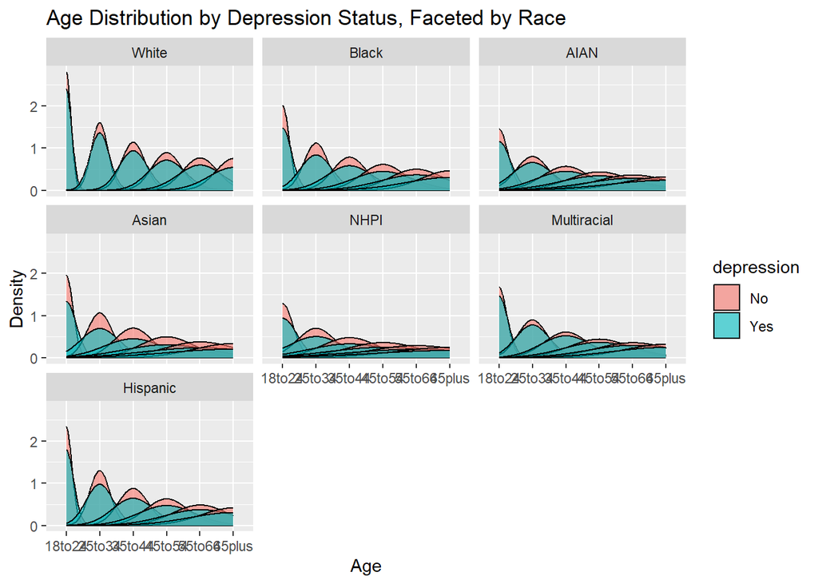

```r
data %>%
  filter(!is.na(depression), !is.na(age), !is.na(race)) %>%
  ggplot(aes(x = age, fill = depression)) +
  geom_density(alpha = 0.6) +
  facet_wrap(~ race) +
  labs(title = "Age Distribution by Depression Status, Faceted by Race",
       x = "Age", y = "Density")
```